# Intermediate R, Session 2

Bioinformatics Resource Center - Rockefeller University

http://rockefelleruniversity.github.io/RU_course_template/

brc@rockefeller.edu

# Intermediate R (part 2)

## Plan

- [Getting started with tidy](https://rockefelleruniversity.github.io/Intermediate_R/r_course/presentations/singlepage/Intermediate_R_Session1.html#data-wrangling-with-the-tidyverse)
- Reading with readr
- Manipulating data with dplyr
- Miscellaneous tools for tidying data with tibble and tidyr
- [Data clean up and string operations with stringr](https://rockefelleruniversity.github.io/Intermediate_R/r_course/presentations/singlepage/Intermediate_R_Session1.html#stringr)
- Vecotrized iterations with purrr
- Working with factors with forcats

# Making R easier with Tidyverse

## Data wrangling with the Tidyverse

**There are some problems we face often when dealing with data.**

- Every dataset is different. Sometimes very different.
- There are many ways to do things. Everyone has their favorite syntax.

**The issue:** Many fundamental data processing functions exist in *Base R* and beyond. Sometimes they can be inconsistent or unnecessarily complex. Especially when dealing with non-standard dataframes. The result is code that is confusing and doesn’t flow i.e. nested functions

## What does it mean to be tidy?

Tidyverse is most importantly a philosophy for data analysis that more often then not makes wrangling data easier. The tidyverse community have built what they describe as an *opinionated* group of packages. These packages readily talk to one another.

- More efficient code
- Easier to remember syntax
- Easier to read syntax

You can read their [manifesto](https://cran.r-project.org/web/packages/tidyverse/vignettes/manifesto.html) to get a better understanding of the tidy ethos.

## What does it *actually* mean to be tidy?

- A defined vision for coding style in R
- A defined vision for data formats in R
- A defined vision for package design in R
- Unified set of community pushing in a cohesive direction
- Critical mass of people to influence the way the whole R community evolves

## What are the main tidy tools?

- ggplot2 – making pretty graphs
- readr – reading data into R
- dplyr – manipulating data
- tibble - working with tibbles
- tidyr – miscellaneous tools for tidying data
- purrr - iterating over data
- stringr – working with strings
- forcats - working with factors

Other tools have now been made by the Tidy community. This community also overlaps with Bioconductor. But the packages above are the linchpins that hold it together.

## What we will be doing today

We will touch on the core utilities of most of these packages, and show some of their most useful functions.

## What we won’t be doing today

We have a seperate course that covers plotting with [ggplot](https://rockefelleruniversity.github.io/Plotting_In_R/). That said we will show you how easily it integrates with Tidyverse.

# Setting Up

## Set Up

All prerequisites, links to material and slides for this course can be found on github.

- [Intermediate R](https://rockefelleruniversity.github.io/Intermediate_R/)

Or can be downloaded as a zip archive from here.

- [Download zip](https://github.com/rockefelleruniversity/Intermediate_R/zipball/master)

## Course content

Once the zip file is unarchived. All presentations as HTML slides and pages, their R code and HTML practical sheets will be available in the directories underneath.

- **presentations/slides/** Presentations as an HTML slide show.
- **presentations/singlepage/** Presentations as an HTML single page.
- **presentations/r_code/** R code in presentations.
- **exercises/** Practicals as HTML pages.
- **answers/** Practicals with answers as HTML pages and R code solutions.

## Set the Working directory

Before running any of the code in the practicals or slides we need to set the working directory to the folder we unarchived.

You may navigate to the unarchived Intermediate_R folder in the Rstudio menu.

**Session -> Set Working Directory -> Choose Directory**

or in the console.

```r
setwd("~/Downloads/Intermediate_R/r_course")
```

## Lets get tidy!

First step lets load in the data we are using today. This Rdata object will load in a few different data frames.

```r
load(file = "data/my_tidy.Rdata")
```

## Are all data frames equal?

```r
head(df1)
```

```
## # A tibble: 6 × 5
##   salmon_id common_name    age_classbylength  length_mm IGF1_ng_ml
##       <dbl> <chr>          <chr>                  <dbl>      <dbl>
## 1     35032 Chinook salmon yearling                 147       41.3
## 2     35035 Sockeye salmon juvenile                 121       NA
## 3     35036 Sockeye salmon juvenile                 112       NA
## 4     35037 Steelhead      juvenile                 220       42.7
## 5     35038 Steelhead      juvenile                 152       NA
## 6     35033 Chinook salmon mixed age juvenile       444       62.1
```

```r
head(df2)
```

```
## # A tibble: 6 × 5
##   salmon_id common_name    age_classbylength  variable   value
##       <dbl> <chr>          <chr>              <fct>      <dbl>
## 1     35032 Chinook salmon yearling           length_mm  147
## 2     35032 Chinook salmon yearling           IGF1_ng_ml  41.3
## 3     35033 Chinook salmon mixed age juvenile length_mm  444
## 4     35033 Chinook salmon mixed age juvenile IGF1_ng_ml  62.1
## 5     35034 Sockeye salmon juvenile           length_mm  139
## 6     35034 Sockeye salmon juvenile           IGF1_ng_ml  NA
```

## Are all data frames equal?

```r
head(df3a)
```

```
## # A tibble: 6 × 5
##   salmon_id common_name    age_classbylength  variable  value
##       <dbl> <chr>          <chr>              <fct>     <dbl>
## 1     35032 Chinook salmon yearling           length_mm   147
## 2     35033 Chinook salmon mixed age juvenile length_mm   444
## 3     35034 Sockeye salmon juvenile           length_mm   139
## 4     35035 Sockeye salmon juvenile           length_mm   121
## 5     35036 Sockeye salmon juvenile           length_mm   112
## 6     35037 Steelhead      juvenile           length_mm   220
```

```r
head(df3b)
```

```
## # A tibble: 6 × 5
##   salmon_id common_name    age_classbylength  variable   value
##       <dbl> <chr>          <chr>              <fct>      <dbl>
## 1     35032 Chinook salmon yearling           IGF1_ng_ml  41.3
## 2     35033 Chinook salmon mixed age juvenile IGF1_ng_ml  62.1
## 3     35034 Sockeye salmon juvenile           IGF1_ng_ml  NA
## 4     35035 Sockeye salmon juvenile           IGF1_ng_ml  NA
## 5     35036 Sockeye salmon juvenile           IGF1_ng_ml  NA
## 6     35037 Steelhead      juvenile           IGF1_ng_ml  42.7
```

## What is a tidy dataset?

A tidy dataset is a data frame (or table) for which the following are true:

- Each variable has its own column
- Each observation has its own row
- Each value has its own cell

## *Which of our dataframes is tidy?*

Our first dataframe is tidy

## Why bother?

Consistent dataframe layouts help to ensure that all values are present and that relationships between data points are clear.

R is a vectorized programming language. R builds data frames from vectors, and R works best when its operation are vectorized.

Tidy data utilizes both these aspects of R.  
=> Precise and Fast

## Lets load in the tidyverse

To get started all we have to do is load in the core tidyverse packages, with a library call to tidyverse.

```r
library(tidyverse)
```

## Other library calls

If you just need one of the packages you can also load the packages individually.

```r
library(readr)
```

# Reading and Tibbles

## readr: Reading data into R

Now that we have our packages loaded in we now need some data. Lets start from the beginning by reading in some data.

## Reading in with base

We can use several functions to read files in using base R like read.csv, read.table, read.delim etc. These have overlapping uses that are context dependent.

When you read data in with base, it goes into a regular dataframe. When you return the dataframe through typing it in the console it will just print the whole dataframe.

```r
untidy_counts_base <- read.csv("data/hemato_rnaseq_counts.csv")

untidy_counts_base
```

```
##     ENTREZ CD34_1 ORTHO_1 CD34_2 ORTHO_2
## 1      350    204       0    103       0
## 2      351  15586     479  10476      39
## 3      353    842     355   1188      86
## 4      354      0       0      0       0
## 5      355    123     291    139      16
## 6      356      1       1      0       0
## 7      357    380       3    177       0
## 8      358    572    2225    597    4051
## 9      359      0      12      1       0
## 10     360    320     502     46    1114
## 11     361      0       1      0       0
## 12     362      3       1     15       0
## 13     363     14       6      4       1
## 14     364      7       0      1       0
```

[output cut: 86 more lines]

## Reading in with readr

As with base There are several functions to read in data. One quick note is that you will see many analogous function names to base, but typically in tidyverse they use a *_* instead of *.* i.e. read_csv() instead of read.csv().

readr:

- read_csv(): comma separated (CSV) files
- read_tsv(): tab separated files
- read_delim(): general delimited files
- read_table(): tabular files where columns are separated by white-space
- read_lines(): reads a certain number of lines
- read_csv_chunked(): read csv files, but do it in chunks (for very large files)

## Reading in with readr

When you use readr to read in your data, you instead get a special dataframe called a tibble. Tibbles have several properties that make them more user friendly i.e. When you return the tibble through typing it in the console it will print a preview, with some information about dimensions and data types.

```r
read_csv("data/hemato_rnaseq_counts.csv")
```

```
## # A tibble: 100 × 5
##    ENTREZ CD34_1 ORTHO_1 CD34_2 ORTHO_2
##     <dbl>  <dbl>   <dbl>  <dbl>   <dbl>
##  1    350    204       0    103       0
##  2    351  15586     479  10476      39
##  3    353    842     355   1188      86
##  4    354      0       0      0       0
##  5    355    123     291    139      16
##  6    356      1       1      0       0
##  7    357    380       3    177       0
##  8    358    572    2225    597    4051
##  9    359      0      12      1       0
## 10    360    320     502     46    1114
## # ℹ 90 more rows
```

## Reading in with readr

Tibbles carry and display extra information. While reading in it is easy to specify data type.

```r
untidy_counts <- read_csv("data/hemato_rnaseq_counts.csv", col_types = cols(ENTREZ = col_character(),
    CD34_1 = col_integer(), ORTHO_1 = col_integer(), CD34_2 = col_integer(), ORTHO_2 = col_integer()))

untidy_counts
```

```
## # A tibble: 100 × 5
##    ENTREZ CD34_1 ORTHO_1 CD34_2 ORTHO_2
##    <chr>   <int>   <int>  <int>   <int>
##  1 350       204       0    103       0
##  2 351     15586     479  10476      39
##  3 353       842     355   1188      86
##  4 354         0       0      0       0
##  5 355       123     291    139      16
##  6 356         1       1      0       0
##  7 357       380       3    177       0
##  8 358       572    2225    597    4051
##  9 359         0      12      1       0
## 10 360       320     502     46    1114
## # ℹ 90 more rows
```

## Subsetting to make tibbles

You can use the same methods as base R to interact with tibbles to subset them.

```r
untidy_counts[1, ]
```

```
## # A tibble: 1 × 5
##   ENTREZ CD34_1 ORTHO_1 CD34_2 ORTHO_2
##   <chr>   <int>   <int>  <int>   <int>
## 1 350       204       0    103       0
```

```r
untidy_counts[, 1]
```

```
## # A tibble: 100 × 1
##    ENTREZ
##    <chr>
##  1 350
##  2 351
##  3 353
##  4 354
##  5 355
##  6 356
##  7 357
##  8 358
##  9 359
## 10 360
## # ℹ 90 more rows
```

## Subsetting to make tibbles

Tibbles are column-oriented, so if you don’t specify row/column with a comma, it will assume you want a column.

```r
untidy_counts[1]
```

```
## # A tibble: 100 × 1
##    ENTREZ
##    <chr>
##  1 350
##  2 351
##  3 353
##  4 354
##  5 355
##  6 356
##  7 357
##  8 358
##  9 359
## 10 360
## # ℹ 90 more rows
```

## Subsetting to make vectors

The outputs thus far have produced more tibbles. Sometimes we just want a vector. Like lists, we can use double brackets. Again this will give the first column.

```r
untidy_counts[[1]]
```

```
##   [1] "350" "351" "353" "354" "355" "356" "357" "358" "359" "360" "361" "362"
##  [13] "363" "364" "366" "367" "368" "369" "372" "373" "374" "375" "377" "378"
##  [25] "379" "381" "382" "383" "384" "387" "388" "389" "390" "391" "392" "393"
##  [37] "394" "395" "396" "397" "398" "399" "400" "401" "402" "403" "405" "406"
##  [49] "407" "408" "409" "410" "411" "412" "414" "415" "416" "417" "419" "420"
##  [61] "421" "427" "429" "430" "432" "433" "434" "435" "440" "443" "444" "445"
##  [73] "460" "462" "463" "466" "467" "468" "471" "472" "473" "474" "475" "476"
##  [85] "477" "478" "479" "480" "481" "482" "483" "486" "487" "488" "489" "490"
##  [97] "491" "492" "493" "495"
```

## Subsetting to make vectors

Also, like lists and regular data frames we can use a dollar sign with the column name.

```r
untidy_counts$ENTREZ
```

```
##   [1] "350" "351" "353" "354" "355" "356" "357" "358" "359" "360" "361" "362"
##  [13] "363" "364" "366" "367" "368" "369" "372" "373" "374" "375" "377" "378"
##  [25] "379" "381" "382" "383" "384" "387" "388" "389" "390" "391" "392" "393"
##  [37] "394" "395" "396" "397" "398" "399" "400" "401" "402" "403" "405" "406"
##  [49] "407" "408" "409" "410" "411" "412" "414" "415" "416" "417" "419" "420"
##  [61] "421" "427" "429" "430" "432" "433" "434" "435" "440" "443" "444" "445"
##  [73] "460" "462" "463" "466" "467" "468" "471" "472" "473" "474" "475" "476"
##  [85] "477" "478" "479" "480" "481" "482" "483" "486" "487" "488" "489" "490"
##  [97] "491" "492" "493" "495"
```

## Tibbles: Converting to tibble

There are coercion functions similar to base to convert a regular dataframe to a tibble.

```r
as_tibble(untidy_counts_base)
```

```
## # A tibble: 100 × 5
##    ENTREZ CD34_1 ORTHO_1 CD34_2 ORTHO_2
##     <int>  <int>   <int>  <int>   <int>
##  1    350    204       0    103       0
##  2    351  15586     479  10476      39
##  3    353    842     355   1188      86
##  4    354      0       0      0       0
##  5    355    123     291    139      16
##  6    356      1       1      0       0
##  7    357    380       3    177       0
##  8    358    572    2225    597    4051
##  9    359      0      12      1       0
## 10    360    320     502     46    1114
## # ℹ 90 more rows
```

## Tibbles: Converting from tibble

Some tools are not tibble friendly. Calling as.data.frame is sufficient to convert it back to a base data frame

```r
untidy_counts_df <- as.data.frame(untidy_counts)
head(untidy_counts_df)
```

```
##   ENTREZ CD34_1 ORTHO_1 CD34_2 ORTHO_2
## 1    350    204       0    103       0
## 2    351  15586     479  10476      39
## 3    353    842     355   1188      86
## 4    354      0       0      0       0
## 5    355    123     291    139      16
## 6    356      1       1      0       0
```

## Tibbles: Make your own

We can also make our own tibble now from scratch. Lets use some genome metadata. We are accessing some Bioconductor databases that contain annotation information for genes.

First we grab the position of genes. Then we use the IDs to get gene symbols. For more info on what we are doing check out our Bioconductor course [here](https://rockefelleruniversity.github.io/Bioconductor_Introduction/presentations/singlepage/GenomicFeatures_In_Bioconductor.html#Extracting_Genomic_Locations)

```r
# Lets load in some packages
library(org.Hs.eg.db)
library(TxDb.Hsapiens.UCSC.hg38.knownGene)

hg38_genes <- genes(TxDb.Hsapiens.UCSC.hg38.knownGene)
```

```
##   2169 genes were dropped because they have exons located on both strands of
##   the same reference sequence or on more than one reference sequence, so cannot
##   be represented by a single genomic range.
##   Use 'single.strand.genes.only=FALSE' to get all the genes in a GRangesList
##   object, or use suppressMessages() to suppress this message.
```

```r
keys <- hg38_genes$gene_id

symbols <- AnnotationDbi::select(org.Hs.eg.db, keys = keys, columns = c("SYMBOL"),
    keytype = "ENTREZID")
```

## Tibbles: Make your own

Now we will put all the metadata together into a tibble.

```r
counts_metadata <- tibble(ID = symbols$ENTREZID, SYMBOL = symbols$SYMBOL, LENGTH = lengths(hg38_genes))

counts_metadata
```

```
## # A tibble: 35,356 × 3
##    ID        SYMBOL     LENGTH
##    <chr>     <chr>       <int>
##  1 1         A1BG        17574
##  2 10        NAT2        14946
##  3 100       ADA         67357
##  4 1000      CDH2       245068
##  5 100008586 GAGE12F     16941
##  6 100008587 RNA5-8SN5     153
##  7 100009613 LINC02584   13282
##  8 100009667 POU5F1P5      658
##  9 100009676 ZBTB11-AS1   2797
## 10 10001     MED6        59948
## # ℹ 35,346 more rows
```

# Tidying up your data

## Tidying data up

Now we know how to read data in weill want to tidy it. What is wrong with the count dataframe from a tidy viewpoint?

*Remember*. These are the rules:

- Each variable has its own column
- Each observation has its own row
- Each value has its own cell

```r
untidy_counts
```

```
## # A tibble: 100 × 5
##    ENTREZ CD34_1 ORTHO_1 CD34_2 ORTHO_2
##    <chr>   <int>   <int>  <int>   <int>
##  1 350       204       0    103       0
##  2 351     15586     479  10476      39
##  3 353       842     355   1188      86
##  4 354         0       0      0       0
##  5 355       123     291    139      16
##  6 356         1       1      0       0
##  7 357       380       3    177       0
##  8 358       572    2225    597    4051
##  9 359         0      12      1       0
## 10 360       320     502     46    1114
## # ℹ 90 more rows
```

## Tidying data up

What is wrong with the count dataframe from a tidy viewpoint?

*Remember*, these are the rules:

- Each variable has its own column
- Each observation has its own row
- Each value has its own cell

**A single variable with multiple columns**

```r
untidy_counts
```

```
## # A tibble: 100 × 5
##    ENTREZ CD34_1 ORTHO_1 CD34_2 ORTHO_2
##    <chr>   <int>   <int>  <int>   <int>
##  1 350       204       0    103       0
##  2 351     15586     479  10476      39
##  3 353       842     355   1188      86
##  4 354         0       0      0       0
##  5 355       123     291    139      16
##  6 356         1       1      0       0
##  7 357       380       3    177       0
##  8 358       572    2225    597    4051
##  9 359         0      12      1       0
## 10 360       320     502     46    1114
## # ℹ 90 more rows
```

## Reshape data with pivot_*

In this case we have multiple samples as columns. Though this is intuitive for some analyses and plotting, often this is not what we want and it is untidy. When all the data is in the wrong orientation, tidyr has some tools to move the data around quickly and easily:

**pivot_longer and pivot_wider**

```
## # A tibble: 400 × 3
##    ENTREZ Sample  counts
##    <chr>  <chr>    <int>
##  1 350    CD34_1     204
##  2 350    ORTHO_1      0
##  3 350    CD34_2     103
##  4 350    ORTHO_2      0
##  5 351    CD34_1   15586
##  6 351    ORTHO_1    479
##  7 351    CD34_2   10476
##  8 351    ORTHO_2     39
##  9 353    CD34_1     842
## 10 353    ORTHO_1    355
## # ℹ 390 more rows
```

## tidyr::pivot_longer

In this case, pivot_longer creates new columns Sample and Counts. Sample is made from the column names hence *names_to*. While Counts is made from the values within the columns hence *values_to*. We are also specifying that we are tidying all columns apart from ENTREZ with the cols argument.

**This replaced a function called gather**

```r
tidier_counts <- pivot_longer(untidy_counts, names_to = "Sample", values_to = "counts",
    cols = c(-ENTREZ))
tidier_counts
```

```
## # A tibble: 400 × 3
##    ENTREZ Sample  counts
##    <chr>  <chr>    <int>
##  1 350    CD34_1     204
##  2 350    ORTHO_1      0
##  3 350    CD34_2     103
##  4 350    ORTHO_2      0
##  5 351    CD34_1   15586
##  6 351    ORTHO_1    479
##  7 351    CD34_2   10476
##  8 351    ORTHO_2     39
##  9 353    CD34_1     842
## 10 353    ORTHO_1    355
## # ℹ 390 more rows
```

## tidyr::pivot_wider

pivot_wider allows you to go in the opposite direction to pivot_longer. We can spread single variables over multiple columns. Intuitively we use the arguments: *names_from* and *values_from*, to determine which columns we are getting arguments from.

**This replaced a function called spread**

```r
pivot_wider(tidier_counts, names_from = c(Sample), values_from = counts)
```

```
## # A tibble: 100 × 5
##    ENTREZ CD34_1 ORTHO_1 CD34_2 ORTHO_2
##    <chr>   <int>   <int>  <int>   <int>
##  1 350       204       0    103       0
##  2 351     15586     479  10476      39
##  3 353       842     355   1188      86
##  4 354         0       0      0       0
##  5 355       123     291    139      16
##  6 356         1       1      0       0
##  7 357       380       3    177       0
##  8 358       572    2225    597    4051
##  9 359         0      12      1       0
## 10 360       320     502     46    1114
## # ℹ 90 more rows
```

## What is next to tidy?

*Remember*, these are the rules:

- Each variable has its own column
- Each observation has its own row
- Each value has its own cell

```r
tidier_counts
```

```
## # A tibble: 400 × 3
##    ENTREZ Sample  counts
##    <chr>  <chr>    <int>
##  1 350    CD34_1     204
##  2 350    ORTHO_1      0
##  3 350    CD34_2     103
##  4 350    ORTHO_2      0
##  5 351    CD34_1   15586
##  6 351    ORTHO_1    479
##  7 351    CD34_2   10476
##  8 351    ORTHO_2     39
##  9 353    CD34_1     842
## 10 353    ORTHO_1    355
## # ℹ 390 more rows
```

## What is next to tidy?

*Remember*, these are the rules:

- Each variable has its own column
- Each observation has its own row
- Each value has its own cell

**Multiple variables in a single column**

```r
tidier_counts
```

```
## # A tibble: 400 × 3
##    ENTREZ Sample  counts
##    <chr>  <chr>    <int>
##  1 350    CD34_1     204
##  2 350    ORTHO_1      0
##  3 350    CD34_2     103
##  4 350    ORTHO_2      0
##  5 351    CD34_1   15586
##  6 351    ORTHO_1    479
##  7 351    CD34_2   10476
##  8 351    ORTHO_2     39
##  9 353    CD34_1     842
## 10 353    ORTHO_1    355
## # ℹ 390 more rows
```

## Splitting and combining varaibles

When there are several variables crammed into a single column, tidyr can be used to split single values into several:

**separate**

## tidyr::separate

Separate allows you to break a strings in a variable by a separator. In this case the cell type and replicate number are broken by underscore.

**There are also the newer functions: separate_wider_delim(), separate_wider_position(), separate_wider_regex()**

```r
tidy_counts <- separate(tidier_counts, Sample, sep = "_", into = c("CellType", "Rep"),
    remove = TRUE)
tidy_counts
```

```
## # A tibble: 400 × 4
##    ENTREZ CellType Rep   counts
##    <chr>  <chr>    <chr>  <int>
##  1 350    CD34     1        204
##  2 350    ORTHO    1          0
##  3 350    CD34     2        103
##  4 350    ORTHO    2          0
##  5 351    CD34     1      15586
##  6 351    ORTHO    1        479
##  7 351    CD34     2      10476
##  8 351    ORTHO    2         39
##  9 353    CD34     1        842
## 10 353    ORTHO    1        355
## # ℹ 390 more rows
```

## tidyr::unite

Unite can go the other way. The *remove* argument controls whether the arguments that are being united are also dropped in the new object. This is especially useful if you want to combine variables to make a specific sample ID.

```r
unite(tidy_counts, Sample, CellType, Rep, remove = FALSE)
```

```
## # A tibble: 400 × 5
##    ENTREZ Sample  CellType Rep   counts
##    <chr>  <chr>   <chr>    <chr>  <int>
##  1 350    CD34_1  CD34     1        204
##  2 350    ORTHO_1 ORTHO    1          0
##  3 350    CD34_2  CD34     2        103
##  4 350    ORTHO_2 ORTHO    2          0
##  5 351    CD34_1  CD34     1      15586
##  6 351    ORTHO_1 ORTHO    1        479
##  7 351    CD34_2  CD34     2      10476
##  8 351    ORTHO_2 ORTHO    2         39
##  9 353    CD34_1  CD34     1        842
## 10 353    ORTHO_1 ORTHO    1        355
## # ℹ 390 more rows
```

# Piping with Magrittr

## Simplifying code

Often when getting started code can get a little out of control and confusing. As additional steps are added code can become nested. For example here we tidy our data in a single complicated expression

```r
tidy_counts <- separate(pivot_longer(untidy_counts, names_to = "Sample", values_to = "counts",
    cols = c(-ENTREZ)), Sample, sep = "_", into = c("CellType", "Rep"), remove = FALSE)
```

We simplified things by saving each step as an intermediate. This is not very efficient as your memory will fill up.

```r
tidier_counts <- pivot_longer(untidy_counts, names_to = "Sample", values_to = "counts",
    cols = c(-ENTREZ))
tidy_counts <- separate(tidier_counts, Sample, sep = "_", into = c("CellType", "Rep"),
    remove = FALSE)
```

## Piping to string functions together

Piping allows you to pass the result from one expression directly into another. This is a common operation used across computational languages that strings together expressions so you do not need to save any transient files. Piping is integral to tidyverse.

How does this work with R? We follow a specific logical flow:

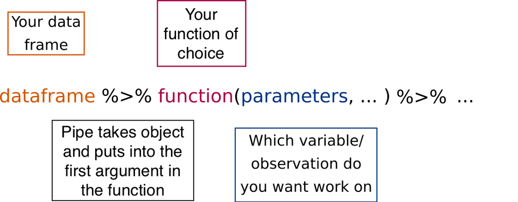

dplyr

## Piping in base R

R added native in-built piping options in 2021 using **|>**.

This way there are no intermediates and the steps in your data analysis are logical and clear unlike nested code.

```r
tidy_counts <- untidy_counts |> # start with untidy counts
  pivot_longer(cols= 2:5,  names_to ="Sample", values_to = "counts") |> # pivot tibble to a single count column
  separate(Sample, sep = "_", into = c("CellType","Rep"), remove=FALSE) # split metadata
tidy_counts
```

```
## # A tibble: 400 × 5
##    ENTREZ Sample  CellType Rep   counts
##    <chr>  <chr>   <chr>    <chr>  <int>
##  1 350    CD34_1  CD34     1        204
##  2 350    ORTHO_1 ORTHO    1          0
##  3 350    CD34_2  CD34     2        103
##  4 350    ORTHO_2 ORTHO    2          0
##  5 351    CD34_1  CD34     1      15586
##  6 351    ORTHO_1 ORTHO    1        479
##  7 351    CD34_2  CD34     2      10476
##  8 351    ORTHO_2 ORTHO    2         39
##  9 353    CD34_1  CD34     1        842
## 10 353    ORTHO_1 ORTHO    1        355
## # ℹ 390 more rows
```

## Piping in tidy

The magrittR package developed the %>% pipe as part of Tidyverse. This pipe is loaded in with the tidyverse. On it’s face value the tidyverse pipe works in a similar way to the base pipe.

```r
tidy_counts <- untidy_counts %>%
    gather(key = Sample, value = counts, -ENTREZ) %>%
    separate(Sample, sep = "_", into = c("CellType", "Rep"), remove = FALSE)
tidy_counts
```

```
## # A tibble: 400 × 5
##    ENTREZ Sample CellType Rep   counts
##    <chr>  <chr>  <chr>    <chr>  <int>
##  1 350    CD34_1 CD34     1        204
##  2 351    CD34_1 CD34     1      15586
##  3 353    CD34_1 CD34     1        842
##  4 354    CD34_1 CD34     1          0
##  5 355    CD34_1 CD34     1        123
##  6 356    CD34_1 CD34     1          1
##  7 357    CD34_1 CD34     1        380
##  8 358    CD34_1 CD34     1        572
##  9 359    CD34_1 CD34     1          0
## 10 360    CD34_1 CD34     1        320
## # ℹ 390 more rows
```

## Advanced Piping

Often the tidyverse pipe is more popular. The magrittR package developed the %>% pipe as part of Tidyverse prior to the base R. The RStudio shortcut Ctrl+Shift+M also insets the tidyverse pipe by default (though you can change this). That said it is also more flexible.

## Piping and placeholders

A period ( . ) can be used as placeholders to represent the object being piped in. In this case we use the period to in a logical expression, which we then use to subset itself.

```r
tidier_counts %>%
    .[.$counts > 0, ]
```

```
## # A tibble: 330 × 3
##    ENTREZ Sample  counts
##    <chr>  <chr>    <int>
##  1 350    CD34_1     204
##  2 350    CD34_2     103
##  3 351    CD34_1   15586
##  4 351    ORTHO_1    479
##  5 351    CD34_2   10476
##  6 351    ORTHO_2     39
##  7 353    CD34_1     842
##  8 353    ORTHO_1    355
##  9 353    CD34_2    1188
## 10 353    ORTHO_2     86
## # ℹ 320 more rows
```

## Piping and in-place assignment

%<>% is a modification of the pipe. This is a two way pipe that will carry the variable forward, and once expression is resolved, the result then gets assigned back to the original variable. To use this you have to actually load the actual magrittr package in to your work space.

```r
library(magrittr)
tidier_counts %<>%
    .[.$counts > 0, ]
tidier_counts
```

```
## # A tibble: 330 × 3
##    ENTREZ Sample  counts
##    <chr>  <chr>    <int>
##  1 350    CD34_1     204
##  2 350    CD34_2     103
##  3 351    CD34_1   15586
##  4 351    ORTHO_1    479
##  5 351    CD34_2   10476
##  6 351    ORTHO_2     39
##  7 353    CD34_1     842
##  8 353    ORTHO_1    355
##  9 353    CD34_2    1188
## 10 353    ORTHO_2     86
## # ℹ 320 more rows
```

## # Quickly manipulate data with dplyr

## dplyr

Now we know how to tidy data and some core aspects of coding in a tidyverse way, we want to start unleashing the power of using tidyverse for data manipulation. The dplyr package is one of the main workhorses in the tidyverse. This package contains a variety of tools to access and manipulate dataframes.

dplyr makes it easy to merge, subset and summarize data sets quickly.

# Joining tibbles together

## Joining

Often you have two dataframes and you want to join them together. Data frames can be joined on a shared variable *a.k.a.* a key. We want this key to be unique i.e. ENTREZ ID.

## Merging dataframes

Lets start by merging two data frames. Our first input will be our count data.

```r
tidy_counts
```

```
## # A tibble: 400 × 5
##    ENTREZ Sample CellType Rep   counts
##    <chr>  <chr>  <chr>    <chr>  <int>
##  1 350    CD34_1 CD34     1        204
##  2 351    CD34_1 CD34     1      15586
##  3 353    CD34_1 CD34     1        842
##  4 354    CD34_1 CD34     1          0
##  5 355    CD34_1 CD34     1        123
##  6 356    CD34_1 CD34     1          1
##  7 357    CD34_1 CD34     1        380
##  8 358    CD34_1 CD34     1        572
##  9 359    CD34_1 CD34     1          0
## 10 360    CD34_1 CD34     1        320
## # ℹ 390 more rows
```

## Merging dataframes

The second data frame is some additional information associated with each gene.

```r
counts_metadata
```

```
## # A tibble: 35,356 × 3
##    ID        SYMBOL     LENGTH
##    <chr>     <chr>       <int>
##  1 1         A1BG        17574
##  2 10        NAT2        14946
##  3 100       ADA         67357
##  4 1000      CDH2       245068
##  5 100008586 GAGE12F     16941
##  6 100008587 RNA5-8SN5     153
##  7 100009613 LINC02584   13282
##  8 100009667 POU5F1P5      658
##  9 100009676 ZBTB11-AS1   2797
## 10 10001     MED6        59948
## # ℹ 35,346 more rows
```

## dplyr::inner_join

We can use the *inner_join* function from the dplyr package to merge these data frames.

```r
tidy_counts_meta <- inner_join(tidy_counts, counts_metadata, by = c(ENTREZ = "ID"))
```

## There are many ways to join things

Inner Join

- Keeps all observations in x and y with matching keys

Outer Join

- A left join keeps all observations in x and those in y with matching keys.
- A right join keeps all observations in y and those in x with matching keys.
- A full join keeps all observations in x and y

## dplyr::left_join

My tidy_counts tibble is the on the left, so is the backbone for this join. This will only then show the metadata that has a matching key i.e. ENTREZID.

```r
left_join(tidy_counts, counts_metadata, by = c(ENTREZ = "ID"))
```

```
## # A tibble: 400 × 7
##    ENTREZ Sample CellType Rep   counts SYMBOL  LENGTH
##    <chr>  <chr>  <chr>    <chr>  <int> <chr>    <int>
##  1 350    CD34_1 CD34     1        204 APOH     44493
##  2 351    CD34_1 CD34     1      15586 APP     290594
##  3 353    CD34_1 CD34     1        842 APRT      2599
##  4 354    CD34_1 CD34     1          0 KLK3      5850
##  5 355    CD34_1 CD34     1        123 FAS      75793
##  6 356    CD34_1 CD34     1          1 FASLG     7774
##  7 357    CD34_1 CD34     1        380 SHROOM2 163015
##  8 358    CD34_1 CD34     1        572 AQP1     73245
##  9 359    CD34_1 CD34     1          0 AQP2      8142
## 10 360    CD34_1 CD34     1        320 AQP3      6441
## # ℹ 390 more rows
```

## dplyr::right_join

Now the counts_metadata tibble is the backbone for this join. Many of the keys (i.e. ENTREZID) in this tibble do not have matches in the tidy_counts_tibble. Anything without a match is filled in with NA.

```r
tidy_counts_expressed <- right_join(tidy_counts, counts_metadata, by = c(ENTREZ = "ID"))
tidy_counts_expressed %>%
    tail()
```

```
## # A tibble: 6 × 7
##   ENTREZ Sample CellType Rep   counts SYMBOL  LENGTH
##   <chr>  <chr>  <chr>    <chr>  <int> <chr>    <int>
## 1 999    <NA>   <NA>     <NA>      NA CDH1     98246
## 2 9990   <NA>   <NA>     <NA>      NA SLC12A6 108277
## 3 9991   <NA>   <NA>     <NA>      NA PTBP3   118583
## 4 9992   <NA>   <NA>     <NA>      NA KCNE2   190653
## 5 9993   <NA>   <NA>     <NA>      NA DGCR2    86173
## 6 9997   <NA>   <NA>     <NA>      NA SCO2      2894
```

## Join vs. Merge

It is possible to do this using in base R using the *merge()* function. The various joins are achieved by controlling specific arguments with this function.

The use of explicit join functions in tidyverse makes data workflows much clearer and readable.

More complex joining operations are also easier to achieve such as filtering joins.

## Filtering joins

Filtering joins

- A semi join only keeps all observations in x that are matched in y. y isn’t returned.
- A anti join only keeps all observations in x that are *not* matched in y. y isn’t returned.

## dplyr::semi_join

Semi join only keeps observations in x that are matched in y. y is only used as a reference and is not in output

```r
semi_join(counts_metadata, tidy_counts, by = c(ID = "ENTREZ"))
```

```
## # A tibble: 99 × 3
##    ID    SYMBOL  LENGTH
##    <chr> <chr>    <int>
##  1 350   APOH     44493
##  2 351   APP     290594
##  3 353   APRT      2599
##  4 354   KLK3      5850
##  5 355   FAS      75793
##  6 356   FASLG     7774
##  7 357   SHROOM2 163015
##  8 358   AQP1     73245
##  9 359   AQP2      8142
## 10 360   AQP3      6441
## # ℹ 89 more rows
```

## dplyr::anti_join

Anti join only keeps observations in x that are not matched in y. y is only used as a reference and is not in output

```r
anti_join(counts_metadata, tidy_counts, by = c(ID = "ENTREZ"))
```

```
## # A tibble: 35,257 × 3
##    ID        SYMBOL     LENGTH
##    <chr>     <chr>       <int>
##  1 1         A1BG        17574
##  2 10        NAT2        14946
##  3 100       ADA         67357
##  4 1000      CDH2       245068
##  5 100008586 GAGE12F     16941
##  6 100008587 RNA5-8SN5     153
##  7 100009613 LINC02584   13282
##  8 100009667 POU5F1P5      658
##  9 100009676 ZBTB11-AS1   2797
## 10 10001     MED6        59948
## # ℹ 35,247 more rows
```

## # Filtering, Summarizing and Modifying

## dplyr

This package contains a variety of tools to access and manipulate dataframes.

They have a common rationale:

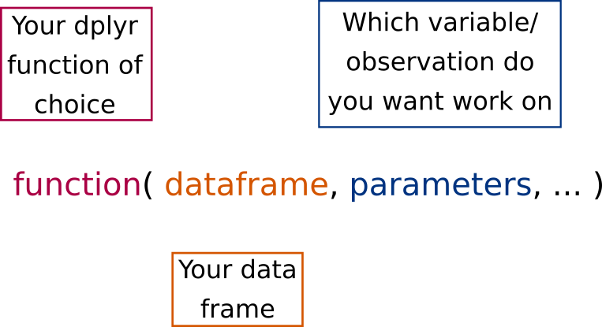

dplyr

## dplyr::select

**select** allows you to work with the columns in your tibble. At its most basic **select** allows you to make a vector from a specific variable.

*NOTE: We are directly pointing to the select function within dplyr by using two semi-colons. We have to do this if we have multiple packages loaded in with the same name. This is really common with the select function as it is quite a generic name.*

```r
dplyr::select(tidy_counts_meta, counts)
```

```
## # A tibble: 396 × 1
##    counts
##     <int>
##  1    204
##  2  15586
##  3    842
##  4      0
##  5    123
##  6      1
##  7    380
##  8    572
##  9      0
## 10    320
## # ℹ 386 more rows
```

## dplyr::select

**select** allows you to make a dataframe from several variables

```r
dplyr::select(tidy_counts_meta, counts, ENTREZ)
```

```
## # A tibble: 396 × 2
##    counts ENTREZ
##     <int> <chr>
##  1    204 350
##  2  15586 351
##  3    842 353
##  4      0 354
##  5    123 355
##  6      1 356
##  7    380 357
##  8    572 358
##  9      0 359
## 10    320 360
## # ℹ 386 more rows
```

## dplyr::select

**select** allows you to make a dataframe excluding a variable

```r
dplyr::select(tidy_counts_meta, -Sample)
```

```
## # A tibble: 396 × 6
##    ENTREZ CellType Rep   counts SYMBOL  LENGTH
##    <chr>  <chr>    <chr>  <int> <chr>    <int>
##  1 350    CD34     1        204 APOH     44493
##  2 351    CD34     1      15586 APP     290594
##  3 353    CD34     1        842 APRT      2599
##  4 354    CD34     1          0 KLK3      5850
##  5 355    CD34     1        123 FAS      75793
##  6 356    CD34     1          1 FASLG     7774
##  7 357    CD34     1        380 SHROOM2 163015
##  8 358    CD34     1        572 AQP1     73245
##  9 359    CD34     1          0 AQP2      8142
## 10 360    CD34     1        320 AQP3      6441
## # ℹ 386 more rows
```

## dplyr::select

**select** allows you to make a dataframe from a range of variables

```r
dplyr::select(tidy_counts_meta, CellType:SYMBOL)
```

```
## # A tibble: 396 × 4
##    CellType Rep   counts SYMBOL
##    <chr>    <chr>  <int> <chr>
##  1 CD34     1        204 APOH
##  2 CD34     1      15586 APP
##  3 CD34     1        842 APRT
##  4 CD34     1          0 KLK3
##  5 CD34     1        123 FAS
##  6 CD34     1          1 FASLG
##  7 CD34     1        380 SHROOM2
##  8 CD34     1        572 AQP1
##  9 CD34     1          0 AQP2
## 10 CD34     1        320 AQP3
## # ℹ 386 more rows
```

## dplyr::filter

**filter** allows you to work with the rows in your tibble. This is my most commonly used dplyr function. Through **filter** you can access observations based on criteria that produces a logical.

```r
filter(tidy_counts_meta, Sample == "CD34_1")
```

```
## # A tibble: 99 × 7
##    ENTREZ Sample CellType Rep   counts SYMBOL  LENGTH
##    <chr>  <chr>  <chr>    <chr>  <int> <chr>    <int>
##  1 350    CD34_1 CD34     1        204 APOH     44493
##  2 351    CD34_1 CD34     1      15586 APP     290594
##  3 353    CD34_1 CD34     1        842 APRT      2599
##  4 354    CD34_1 CD34     1          0 KLK3      5850
##  5 355    CD34_1 CD34     1        123 FAS      75793
##  6 356    CD34_1 CD34     1          1 FASLG     7774
##  7 357    CD34_1 CD34     1        380 SHROOM2 163015
##  8 358    CD34_1 CD34     1        572 AQP1     73245
##  9 359    CD34_1 CD34     1          0 AQP2      8142
## 10 360    CD34_1 CD34     1        320 AQP3      6441
## # ℹ 89 more rows
```

## dplyr::filter

Here we use **filter** to access observations based on several criteria.

```r
filter(tidy_counts_meta, Sample %in% c("CD34_1", "ORTHO_1"))
```

```
## # A tibble: 198 × 7
##    ENTREZ Sample CellType Rep   counts SYMBOL  LENGTH
##    <chr>  <chr>  <chr>    <chr>  <int> <chr>    <int>
##  1 350    CD34_1 CD34     1        204 APOH     44493
##  2 351    CD34_1 CD34     1      15586 APP     290594
##  3 353    CD34_1 CD34     1        842 APRT      2599
##  4 354    CD34_1 CD34     1          0 KLK3      5850
##  5 355    CD34_1 CD34     1        123 FAS      75793
##  6 356    CD34_1 CD34     1          1 FASLG     7774
##  7 357    CD34_1 CD34     1        380 SHROOM2 163015
##  8 358    CD34_1 CD34     1        572 AQP1     73245
##  9 359    CD34_1 CD34     1          0 AQP2      8142
## 10 360    CD34_1 CD34     1        320 AQP3      6441
## # ℹ 188 more rows
```

## dplyr::filter

Similarly we can use **filter** to access observations based on numerical operators

```r
filter(tidy_counts_meta, counts > 0)
```

```
## # A tibble: 328 × 7
##    ENTREZ Sample CellType Rep   counts SYMBOL  LENGTH
##    <chr>  <chr>  <chr>    <chr>  <int> <chr>    <int>
##  1 350    CD34_1 CD34     1        204 APOH     44493
##  2 351    CD34_1 CD34     1      15586 APP     290594
##  3 353    CD34_1 CD34     1        842 APRT      2599
##  4 355    CD34_1 CD34     1        123 FAS      75793
##  5 356    CD34_1 CD34     1          1 FASLG     7774
##  6 357    CD34_1 CD34     1        380 SHROOM2 163015
##  7 358    CD34_1 CD34     1        572 AQP1     73245
##  8 360    CD34_1 CD34     1        320 AQP3      6441
##  9 362    CD34_1 CD34     1          3 AQP5      3811
## 10 363    CD34_1 CD34     1         14 AQP6      9946
## # ℹ 318 more rows
```

## dplyr::arrange

*arrange* sorts the dataframe based on a specific variable, in ascending order.

```r
arrange(tidy_counts_meta, counts)
```

```
## # A tibble: 396 × 7
##    ENTREZ Sample  CellType Rep   counts SYMBOL  LENGTH
##    <chr>  <chr>   <chr>    <chr>  <int> <chr>    <int>
##  1 354    CD34_1  CD34     1          0 KLK3      5850
##  2 359    CD34_1  CD34     1          0 AQP2      8142
##  3 361    CD34_1  CD34     1          0 AQP4     13729
##  4 398    CD34_1  CD34     1          0 ARHGDIG  14284
##  5 401    CD34_1  CD34     1          0 PHOX2A    6588
##  6 417    CD34_1  CD34     1          0 ART1     19289
##  7 429    CD34_1  CD34     1          0 ASCL1     2840
##  8 474    CD34_1  CD34     1          0 ATOH1     2212
##  9 495    CD34_1  CD34     1          0 ATP4A    13628
## 10 350    ORTHO_1 ORTHO    1          0 APOH     44493
## # ℹ 386 more rows
```

## dplyr::arrange

*arrange* can sort based on multiple variables using the order provided. We can also use the desc() function to change the order to descending.

```r
arrange(tidy_counts_meta, CellType, desc(counts))
```

```
## # A tibble: 396 × 7
##    ENTREZ Sample CellType Rep   counts SYMBOL  LENGTH
##    <chr>  <chr>  <chr>    <chr>  <int> <chr>    <int>
##  1 351    CD34_1 CD34     1      15586 APP     290594
##  2 397    CD34_1 CD34     1      12997 ARHGDIB  19698
##  3 388    CD34_1 CD34     1      12598 RHOB      2367
##  4 397    CD34_2 CD34     2      11265 ARHGDIB  19698
##  5 351    CD34_2 CD34     2      10476 APP     290594
##  6 387    CD34_1 CD34     1       8899 RHOA     55363
##  7 468    CD34_1 CD34     1       7991 ATF4      2992
##  8 387    CD34_2 CD34     2       7405 RHOA     55363
##  9 396    CD34_1 CD34     1       6503 ARHGDIA   3660
## 10 468    CD34_2 CD34     2       5307 ATF4      2992
## # ℹ 386 more rows
```

## dplyr::mutate

*mutate* creates a new column based on some form of computation. Here we are adding a z-score for the counts.

```r
mutate(tidy_counts_meta, scale(counts))
```

```
## # A tibble: 396 × 8
##    ENTREZ Sample CellType Rep   counts SYMBOL  LENGTH `scale(counts)`[,1]
##    <chr>  <chr>  <chr>    <chr>  <int> <chr>    <int>               <dbl>
##  1 350    CD34_1 CD34     1        204 APOH     44493             -0.358
##  2 351    CD34_1 CD34     1      15586 APP     290594              7.16
##  3 353    CD34_1 CD34     1        842 APRT      2599             -0.0458
##  4 354    CD34_1 CD34     1          0 KLK3      5850             -0.457
##  5 355    CD34_1 CD34     1        123 FAS      75793             -0.397
##  6 356    CD34_1 CD34     1          1 FASLG     7774             -0.457
##  7 357    CD34_1 CD34     1        380 SHROOM2 163015             -0.272
##  8 358    CD34_1 CD34     1        572 AQP1     73245             -0.178
##  9 359    CD34_1 CD34     1          0 AQP2      8142             -0.457
## 10 360    CD34_1 CD34     1        320 AQP3      6441             -0.301
## # ℹ 386 more rows
```

## dplyr::mutate

*mutate* can be used to create a named variable in much the same way.

```r
mutate(tidy_counts_meta, count_zscore = scale(counts))
```

```
## # A tibble: 396 × 8
##    ENTREZ Sample CellType Rep   counts SYMBOL  LENGTH count_zscore[,1]
##    <chr>  <chr>  <chr>    <chr>  <int> <chr>    <int>            <dbl>
##  1 350    CD34_1 CD34     1        204 APOH     44493          -0.358
##  2 351    CD34_1 CD34     1      15586 APP     290594           7.16
##  3 353    CD34_1 CD34     1        842 APRT      2599          -0.0458
##  4 354    CD34_1 CD34     1          0 KLK3      5850          -0.457
##  5 355    CD34_1 CD34     1        123 FAS      75793          -0.397
##  6 356    CD34_1 CD34     1          1 FASLG     7774          -0.457
##  7 357    CD34_1 CD34     1        380 SHROOM2 163015          -0.272
##  8 358    CD34_1 CD34     1        572 AQP1     73245          -0.178
##  9 359    CD34_1 CD34     1          0 AQP2      8142          -0.457
## 10 360    CD34_1 CD34     1        320 AQP3      6441          -0.301
## # ℹ 386 more rows
```

## dplyr::mutate and across

When we run mutate, we can use the across() function to do a in-place update of a column. In this case we will turn the column CellType into a factor.

```r
tidy_counts_meta %>%
    mutate(across(CellType, factor))
```

```
## # A tibble: 396 × 7
##    ENTREZ Sample CellType Rep   counts SYMBOL  LENGTH
##    <chr>  <chr>  <fct>    <chr>  <int> <chr>    <int>
##  1 350    CD34_1 CD34     1        204 APOH     44493
##  2 351    CD34_1 CD34     1      15586 APP     290594
##  3 353    CD34_1 CD34     1        842 APRT      2599
##  4 354    CD34_1 CD34     1          0 KLK3      5850
##  5 355    CD34_1 CD34     1        123 FAS      75793
##  6 356    CD34_1 CD34     1          1 FASLG     7774
##  7 357    CD34_1 CD34     1        380 SHROOM2 163015
##  8 358    CD34_1 CD34     1        572 AQP1     73245
##  9 359    CD34_1 CD34     1          0 AQP2      8142
## 10 360    CD34_1 CD34     1        320 AQP3      6441
## # ℹ 386 more rows
```

## dplyr::summarize

*Summarize* applies aggregating or summary function to a group i.e. counting. Lets see how many genes we have no counts for in each sample. First we will generate a table of genes with no counts.

```r
filter(tidy_counts_meta, counts == 0)
```

```
## # A tibble: 68 × 7
##    ENTREZ Sample  CellType Rep   counts SYMBOL  LENGTH
##    <chr>  <chr>   <chr>    <chr>  <int> <chr>    <int>
##  1 354    CD34_1  CD34     1          0 KLK3      5850
##  2 359    CD34_1  CD34     1          0 AQP2      8142
##  3 361    CD34_1  CD34     1          0 AQP4     13729
##  4 398    CD34_1  CD34     1          0 ARHGDIG  14284
##  5 401    CD34_1  CD34     1          0 PHOX2A    6588
##  6 417    CD34_1  CD34     1          0 ART1     19289
##  7 429    CD34_1  CD34     1          0 ASCL1     2840
##  8 474    CD34_1  CD34     1          0 ATOH1     2212
##  9 495    CD34_1  CD34     1          0 ATP4A    13628
## 10 350    ORTHO_1 ORTHO    1          0 APOH     44493
## # ℹ 58 more rows
```

## dplyr::summarize

Now we have some data to play with, we do the first key step in summarization: group_by. This adds the *Group* property. When we summarize it will be within these groups i.e. in this case its within Sample.

```r
filter(tidy_counts_meta, counts == 0) %>%
    group_by(Sample)
```

```
## # A tibble: 68 × 7
## # Groups:   Sample [4]
##    ENTREZ Sample  CellType Rep   counts SYMBOL  LENGTH
##    <chr>  <chr>   <chr>    <chr>  <int> <chr>    <int>
##  1 354    CD34_1  CD34     1          0 KLK3      5850
##  2 359    CD34_1  CD34     1          0 AQP2      8142
##  3 361    CD34_1  CD34     1          0 AQP4     13729
##  4 398    CD34_1  CD34     1          0 ARHGDIG  14284
##  5 401    CD34_1  CD34     1          0 PHOX2A    6588
##  6 417    CD34_1  CD34     1          0 ART1     19289
##  7 429    CD34_1  CD34     1          0 ASCL1     2840
##  8 474    CD34_1  CD34     1          0 ATOH1     2212
##  9 495    CD34_1  CD34     1          0 ATP4A    13628
## 10 350    ORTHO_1 ORTHO    1          0 APOH     44493
## # ℹ 58 more rows
```

## dplyr::summarize

Once the tibble has group information we can then summarize over the these groups. We can use the *n()* function to count how many observations there are for each member of our group, Samples.

```r
filter(tidy_counts_expressed, counts == 0) %>%
    group_by(Sample) %>%
    summarise(n())
```

```
## # A tibble: 4 × 2
##   Sample  `n()`
##   <chr>   <int>
## 1 CD34_1      9
## 2 CD34_2      8
## 3 ORTHO_1    21
## 4 ORTHO_2    30
```

## dplyr::summarize

We can use *summarize* to apply more complex aggregating or summary functions i.e. mean. In this case we will calculate the mean gene counts across conditions.

```r
tidy_counts_meta %>%
    group_by(ENTREZ) %>%
    summarise(counts_mean = mean(counts))
```

```
## # A tibble: 99 × 2
##    ENTREZ counts_mean
##    <chr>        <dbl>
##  1 350          76.8
##  2 351        6645
##  3 353         618.
##  4 354           0
##  5 355         142.
##  6 356           0.5
##  7 357         140
##  8 358        1861.
##  9 359           3.25
## 10 360         496.
## # ℹ 89 more rows
```

## dplyr::summarize

We can use also use multiple groups, for *group_by*. We can use this to generate a more useful mean; the mean counts in genes per CellType.

```r
tidy_counts %>%
    group_by(ENTREZ, CellType) %>%
    summarise(counts_mean = mean(counts))
```

```
## # A tibble: 200 × 3
## # Groups:   ENTREZ [100]
##    ENTREZ CellType counts_mean
##    <chr>  <chr>          <dbl>
##  1 350    CD34            154.
##  2 350    ORTHO             0
##  3 351    CD34          13031
##  4 351    ORTHO           259
##  5 353    CD34           1015
##  6 353    ORTHO           220.
##  7 354    CD34              0
##  8 354    ORTHO             0
##  9 355    CD34            131
## 10 355    ORTHO           154.
## # ℹ 190 more rows
```

## dplyr::group_by

```r
tidy_counts_meta %>%
    group_by(Sample) %>%
    filter(order(counts, decreasing = T) <= 3)
```

```
## # A tibble: 12 × 7
## # Groups:   Sample [4]
##    ENTREZ Sample  CellType Rep   counts SYMBOL  LENGTH
##    <chr>  <chr>   <chr>    <chr>  <int> <chr>    <int>
##  1 350    CD34_1  CD34     1        204 APOH     44493
##  2 396    CD34_1  CD34     1       6503 ARHGDIA   3660
##  3 415    CD34_1  CD34     1         20 ARSL     34431
##  4 389    ORTHO_1 ORTHO    1        193 RHOC     10098
##  5 393    ORTHO_1 ORTHO    1        138 ARHGAP4  27633
##  6 472    ORTHO_1 ORTHO    1        628 ATM     146299
##  7 351    CD34_2  CD34     2      10476 APP     290594
##  8 381    CD34_2  CD34     2       1159 ARF5      3315
##  9 419    CD34_2  CD34     2          2 ART3    102865
## 10 391    ORTHO_2 ORTHO    2        164 RHOG     13982
## 11 399    ORTHO_2 ORTHO    2          2 RHOH     55957
## 12 444    ORTHO_2 ORTHO    2         14 ASPH    214085
```

## dplyr::group_by

We can stitch this together to do more complicated operations. In this case I am filtering to observations without 0 counts. I then am grouping by CellType and ENTREZ.

```r
tidy_counts_meta %>%
    filter(counts != 0) %>%
    group_by(CellType, ENTREZ)
```

```
## # A tibble: 328 × 7
## # Groups:   CellType, ENTREZ [173]
##    ENTREZ Sample CellType Rep   counts SYMBOL  LENGTH
##    <chr>  <chr>  <chr>    <chr>  <int> <chr>    <int>
##  1 350    CD34_1 CD34     1        204 APOH     44493
##  2 351    CD34_1 CD34     1      15586 APP     290594
##  3 353    CD34_1 CD34     1        842 APRT      2599
##  4 355    CD34_1 CD34     1        123 FAS      75793
##  5 356    CD34_1 CD34     1          1 FASLG     7774
##  6 357    CD34_1 CD34     1        380 SHROOM2 163015
##  7 358    CD34_1 CD34     1        572 AQP1     73245
##  8 360    CD34_1 CD34     1        320 AQP3      6441
##  9 362    CD34_1 CD34     1          3 AQP5      3811
## 10 363    CD34_1 CD34     1         14 AQP6      9946
## # ℹ 318 more rows
```

## dplyr::group_by

Now that they are grouped by CellType and ENTREZ, we can filter for all genes that have counts greater than 0, in both replicates.

```r
tidy_counts_meta %>%
    filter(counts != 0) %>%
    group_by(CellType, ENTREZ) %>%
    filter(n() > 1)
```

```
## # A tibble: 310 × 7
## # Groups:   CellType, ENTREZ [155]
##    ENTREZ Sample CellType Rep   counts SYMBOL  LENGTH
##    <chr>  <chr>  <chr>    <chr>  <int> <chr>    <int>
##  1 350    CD34_1 CD34     1        204 APOH     44493
##  2 351    CD34_1 CD34     1      15586 APP     290594
##  3 353    CD34_1 CD34     1        842 APRT      2599
##  4 355    CD34_1 CD34     1        123 FAS      75793
##  5 357    CD34_1 CD34     1        380 SHROOM2 163015
##  6 358    CD34_1 CD34     1        572 AQP1     73245
##  7 360    CD34_1 CD34     1        320 AQP3      6441
##  8 362    CD34_1 CD34     1          3 AQP5      3811
##  9 363    CD34_1 CD34     1         14 AQP6      9946
## 10 364    CD34_1 CD34     1          7 AQP7     19504
## # ℹ 300 more rows
```

## Piping and plots

By now it is clear how useful pipes can be, to stitch together the different operations. These pipes can go straight into plots. Here we make a simple X-Y plot to compare counts in our cell types.

```r
p <- tidy_counts_meta %>%
    group_by(ENTREZ, CellType) %>%
    summarise(counts_mean = mean(counts)) %>%
    pivot_wider(names_from = CellType, values_from = counts_mean) %>%
    ggplot(aes(x = CD34, y = ORTHO)) + geom_point()
```

## Piping and plots

By now it is clear how useful pipes can be, to stitch together the different operations. These pipes can go straight into plots. Here we make a simple X-Y plot to compare counts in our cell types.

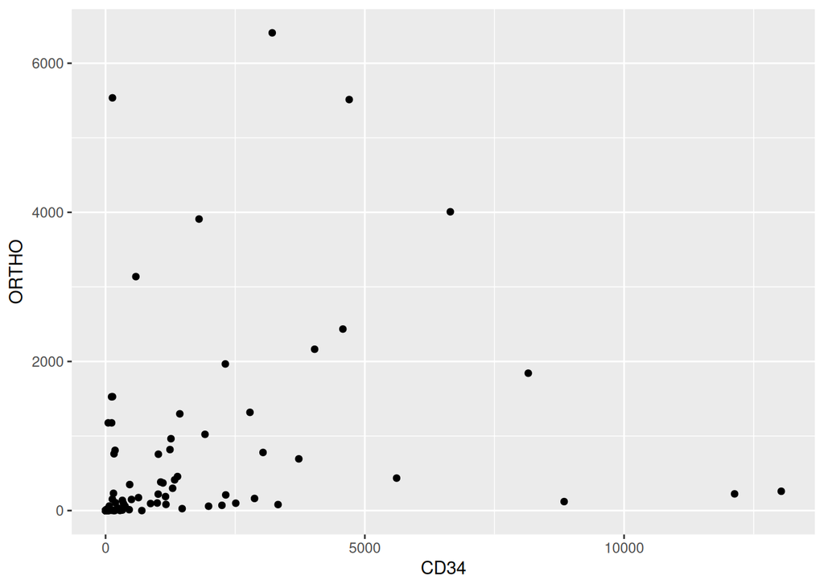

```r
p
```

## # Outputting your tidy data

## Readr again: Writing out

You’ve made a lovely new tibble file. Now you need to save it somewhere. There are a wide range of writing options. We can specify the delmiter directly or use a specific function

```r
write_delim(tidy_counts_meta, "data/counts_with_metadata.csv", delim = ",")

write_csv(tidy_counts_meta, "data/counts_with_metadata.csv")
```

A key difference compared to base is that it does not write out row names. Tibbles generally don’t have rownames.

## # Pattern matching with strings

## stringr

If the data you are working with involves characters from data entry often there will be errors i.e. clinical study metadata or a hand-typed list of genes of interest. Tidying data also means fixing these problems. stringr helps make this easy.

- Access and manipulate characters
- Deal with whitespace
- Pattern Recognition

Though stringr is pretty comprehensive and covers most of what you will need, there is a sister package called stringi with even more functionality.

## stringr::strsub

Many overlapping functions with base for combining, subsetting, converting and finding strings.

Extract substrings from a range. Here the 1st to 3rd character.

```r
brc <- c("Tom", "Jenelys", "Matthew", "Wei", "Doug")


brc %>%
    str_sub(1, 3)
```

```
## [1] "Tom" "Jen" "Mat" "Wei" "Dou"
```

Extract substrings from a range. Here the 2nd to 2nd to last character

```r
brc %>%
    str_sub(2, -2)
```

```
## [1] "o"     "enely" "atthe" "e"     "ou"
```

## stringr::strsub

Many overlapping functions with base for combining, subsetting, converting and finding strings.

Assign values back to substrings. Here the 2nd to 2nd to last character is replaced with X.

```r
str_sub(brc, 2, -2) <- "X"
brc
```

```
## [1] "TXm" "JXs" "MXw" "WXi" "DXg"
```

## Replacing Strings

```r
str_replace_all(brc, "Matthew", "Matt")
```

```
## [1] "TXm" "JXs" "MXw" "WXi" "DXg"
```

```r
str_replace_all(brc, "u", "z")
```

```
## [1] "TXm" "JXs" "MXw" "WXi" "DXg"
```

## Stripping whitespace

Whitespace is often an issue for consistent metadata. WE can use the *str_replace_all* function to remove whitespace.

```r
brc2 <- c("Tom  ", "  Je  nelys", "Matt   ", "Wei", "D o u g")

str_replace_all(brc2, " ", "")
```

```
## [1] "Tom"     "Jenelys" "Matt"    "Wei"     "Doug"
```

Rather then replacing all whitespace, you can trim trailing and leading whitespace from strings.

```r
str_trim(brc2)
```

```
## [1] "Tom"       "Je  nelys" "Matt"      "Wei"       "D o u g"
```

```r
str_pad(brc2, width = 10, side = "left")
```

```
## [1] "     Tom  "  "  Je  nelys" "   Matt   "  "       Wei"  "   D o u g"
```

## stringr::str_to_* - Capitalization

Often when manipulating strings we will also need to alter the capitalization. A common case is if we want to do a quick and easy conversion between gene symbol nomenclature.

```r
tidy_counts_meta %>%
    pull(SYMBOL) %>%
    head()
```

```
## [1] "APOH"  "APP"   "APRT"  "KLK3"  "FAS"   "FASLG"
```

```r
tidy_counts_meta %>%
    pull(SYMBOL) %>%
    str_to_title() %>%
    head()
```

```
## [1] "Apoh"  "App"   "Aprt"  "Klk3"  "Fas"   "Faslg"
```

## stringr::str_to_* - Capitalization

String manipulation can be used with tibbles and mutate.

```r
tidy_counts_meta %>%
    mutate(SYMBOL2 = str_to_title(SYMBOL))
```

```
## # A tibble: 396 × 8
##    ENTREZ Sample CellType Rep   counts SYMBOL  LENGTH SYMBOL2
##    <chr>  <chr>  <chr>    <chr>  <int> <chr>    <int> <chr>
##  1 350    CD34_1 CD34     1        204 APOH     44493 Apoh
##  2 351    CD34_1 CD34     1      15586 APP     290594 App
##  3 353    CD34_1 CD34     1        842 APRT      2599 Aprt
##  4 354    CD34_1 CD34     1          0 KLK3      5850 Klk3
##  5 355    CD34_1 CD34     1        123 FAS      75793 Fas
##  6 356    CD34_1 CD34     1          1 FASLG     7774 Faslg
##  7 357    CD34_1 CD34     1        380 SHROOM2 163015 Shroom2
##  8 358    CD34_1 CD34     1        572 AQP1     73245 Aqp1
##  9 359    CD34_1 CD34     1          0 AQP2      8142 Aqp2
## 10 360    CD34_1 CD34     1        320 AQP3      6441 Aqp3
## # ℹ 386 more rows
```

## stringr::str_to_* - Capitalization

We can convert back to capitals, just as easy.

```r
tidy_counts_meta %>%
    mutate(SYMBOL2 = str_to_title(SYMBOL)) %>%
    mutate(SYMBOL3 = str_to_upper(SYMBOL2))
```

```
## # A tibble: 396 × 9
##    ENTREZ Sample CellType Rep   counts SYMBOL  LENGTH SYMBOL2 SYMBOL3
##    <chr>  <chr>  <chr>    <chr>  <int> <chr>    <int> <chr>   <chr>
##  1 350    CD34_1 CD34     1        204 APOH     44493 Apoh    APOH
##  2 351    CD34_1 CD34     1      15586 APP     290594 App     APP
##  3 353    CD34_1 CD34     1        842 APRT      2599 Aprt    APRT
##  4 354    CD34_1 CD34     1          0 KLK3      5850 Klk3    KLK3
##  5 355    CD34_1 CD34     1        123 FAS      75793 Fas     FAS
##  6 356    CD34_1 CD34     1          1 FASLG     7774 Faslg   FASLG
##  7 357    CD34_1 CD34     1        380 SHROOM2 163015 Shroom2 SHROOM2
##  8 358    CD34_1 CD34     1        572 AQP1     73245 Aqp1    AQP1
##  9 359    CD34_1 CD34     1          0 AQP2      8142 Aqp2    AQP2
## 10 360    CD34_1 CD34     1        320 AQP3      6441 Aqp3    AQP3
## # ℹ 386 more rows
```

## Finding patterns with stringr

Find patterns in different ways. *str_detect* gives a T/F whether the pattern ‘GAP’ is present in vector.

```r
tidy_counts_meta %>%
    pull(SYMBOL) %>%
    str_detect("GAP") %>%
    head()
```

```
## [1] FALSE FALSE FALSE FALSE FALSE FALSE
```

```r
tidy_counts_meta %>%
    pull(SYMBOL) %>%
    str_detect("GAP") %>%
    filter(tidy_counts_meta, .)
```

```
## # A tibble: 16 × 7
##    ENTREZ Sample  CellType Rep   counts SYMBOL  LENGTH
##    <chr>  <chr>   <chr>    <chr>  <int> <chr>    <int>
##  1 392    CD34_1  CD34     1       1527 ARHGAP1  23540
##  2 393    CD34_1  CD34     1       2949 ARHGAP4  27633
##  3 394    CD34_1  CD34     1       1525 ARHGAP5  83615
##  4 395    CD34_1  CD34     1        348 ARHGAP6 548270
##  5 392    ORTHO_1 ORTHO    1        304 ARHGAP1  23540
##  6 393    ORTHO_1 ORTHO    1        138 ARHGAP4  27633
##  7 394    ORTHO_1 ORTHO    1        464 ARHGAP5  83615
##  8 395    ORTHO_1 ORTHO    1         67 ARHGAP6 548270
##  9 392    CD34_2  CD34     2        786 ARHGAP1  23540
## 10 393    CD34_2  CD34     2       1540 ARHGAP4  27633
## 11 394    CD34_2  CD34     2       1062 ARHGAP5  83615
## 12 395    CD34_2  CD34     2        123 ARHGAP6 548270
## 13 392    ORTHO_2 ORTHO    2         71 ARHGAP1  23540
## 14 393    ORTHO_2 ORTHO    2          3 ARHGAP4  27633
## 15 394    ORTHO_2 ORTHO    2        134 ARHGAP5  83615
## 16 395    ORTHO_2 ORTHO    2          0 ARHGAP6 548270
```

## Finding patterns with stringr

*str_subset* is similar to detect, but it returns the match itself.

```r
tidy_counts_meta %>%
    pull(SYMBOL) %>%
    str_subset("GAP")
```

```
##  [1] "ARHGAP1" "ARHGAP4" "ARHGAP5" "ARHGAP6" "ARHGAP1" "ARHGAP4" "ARHGAP5"
##  [8] "ARHGAP6" "ARHGAP1" "ARHGAP4" "ARHGAP5" "ARHGAP6" "ARHGAP1" "ARHGAP4"
## [15] "ARHGAP5" "ARHGAP6"
```

## Finding patterns with stringr

Count gives you the total number of times your pattern appears in each character in the vector.

```r
tidy_counts_meta %>%
    pull(SYMBOL) %>%
    str_count("GAP") %>%
    .[1:100]
```

```
##   [1] 0 0 0 0 0 0 0 0 0 0 0 0 0 0 0 0 0 0 0 0 0 0 0 0 0 0 0 0 0 0 0 0 0 1 1 1 1
##  [38] 0 0 0 0 0 0 0 0 0 0 0 0 0 0 0 0 0 0 0 0 0 0 0 0 0 0 0 0 0 0 0 0 0 0 0 0 0
##  [75] 0 0 0 0 0 0 0 0 0 0 0 0 0 0 0 0 0 0 0 0 0 0 0 0 0 0
```

```r
tidy_counts_meta %>%
    pull(SYMBOL) %>%
    str_count("A") %>%
    .[1:100]
```

```
##   [1] 1 1 1 0 1 1 0 1 1 1 1 1 1 1 1 1 2 1 0 1 1 1 1 1 1 1 1 1 1 0 0 0 0 2 2 2 2
##  [38] 2 1 1 0 1 1 1 1 1 1 1 1 1 2 1 0 1 1 1 1 1 1 1 2 1 1 1 1 1 1 1 2 1 1 1 0 0
##  [75] 1 1 1 1 1 0 1 1 2 2 2 2 2 1 1 1 0 2 2 2 1 1 1 1 2 1
```

## # Functional programming with purrr

## purrr - Functional programming

- Applying functions to datasets
- Base people use *for* loops or apply
- Big advantage is that purrr readily handles nested dataframes and has standard outputs

## purrr::map - tidy way to iterate

Map is the tidy equivalent to apply. Here we take our untidy counts, trim of IDs, and then calculate means for each column. By default the output is a list

```r
untidy_counts %>%
    dplyr::select(-ENTREZ) %>%
    map(mean)
```

```
## $CD34_1
## [1] 1497.67
##
## $ORTHO_1
## [1] 822.33
##
## $CD34_2
## [1] 1056.85
##
## $ORTHO_2
## [1] 329.05
```

## purrr::map_dbl

Same as the above line, but using map_dbl specifies the outputs is going to be a double.

```r
untidy_counts %>%
    dplyr::select(-ENTREZ) %>%
    map_dbl(mean)
```

```
##  CD34_1 ORTHO_1  CD34_2 ORTHO_2
## 1497.67  822.33 1056.85  329.05
```

## purrr::pmap for multiple inputs

```r
list(untidy_counts$ORTHO_1, untidy_counts$ORTHO_2) %>%
    pmap_dbl(mean)
```

```
##   [1]     0   479   355     0   291     1     3  2225    12   502     1     1
##  [13]     6     0     0     0     0  1034  1864   728     5  6697   314  4845
##  [25]     1   574  2265  1632 10977  2457   171   193     0   577   304   138
##  [37]   464    67   702   410     0    11   147     0   218    25   824   175
##  [49]     1   111  1819   197   217    45    15     0     1     0     5  1136
##  [61]   255 11889     0    13     0     0     1   151  2520     0   151    15
##  [73]     0     0   118   480   402  6132   771   628   783     0    83  3453
##  [85]     3   121     0     5    18  1392  1454     0    33  1118   153  1263
##  [97]     1     0  3585     0
```

## Nest - Values can be much more

Dataframes can be be simplified by making them more complex.

Each value within a tibble can contain more abstract information then just numbers and characters. Instead you can store another tibble, or object.

## tidyr::nest

Nest will leverage group information for the nesting the data by sample.

```r
tidy_counts_expressed_norm <- read_csv("data/expressed_genes_output_norm.csv")
tidy_counts_nest <- tidy_counts_expressed_norm %>%
    group_by(Sample) %>%
    nest()

tidy_counts_nest
```

```
## # A tibble: 4 × 2
## # Groups:   Sample [4]
##   Sample  data
##   <chr>   <list>
## 1 CD34_1  <tibble [93 × 10]>
## 2 ORTHO_1 <tibble [93 × 10]>
## 3 CD34_2  <tibble [93 × 10]>
## 4 ORTHO_2 <tibble [93 × 10]>
```

## tidyr::nest

Looking at tibble it is a new datatype that appears simplified.

The data is still there, nested within one of the variables.

```r
tidy_counts_nest$data[[1]]
```

```
## # A tibble: 93 × 10
##    ENTREZ CellType   Rep counts count_total       CPM SYMBOL CHR   LENGTH    TPM
##     <dbl> <chr>    <dbl>  <dbl>       <dbl>     <dbl> <chr>  <chr>  <dbl>  <dbl>
##  1    350 CD34         1    204         307   1362.   APOH   chr17   1332 4.07e3
##  2    351 CD34         1  15586       26580 104088.   APP    chr21   6608 6.26e4
##  3    353 CD34         1    842        2471   5623.   APRT   chr16   1796 1.25e4
##  4    355 CD34         1    123         569    821.   FAS    chr10  29313 1.11e2
##  5    356 CD34         1      1           2      6.68 FASLG  chr1    1805 1.47e1
##  6    357 CD34         1    380         560   2538.   SHROO… chrX    8218 1.23e3
##  7    358 CD34         1    572        7445   3820.   AQP1   chr7    3882 3.91e3
##  8    359 CD34         1      0          13      0    AQP2   chr12   4306 0
##  9    360 CD34         1    320        1982   2137.   AQP3   chr9    2911 2.92e3
## 10    361 CD34         1      0           1      0    AQP4   chr18   5943 0
## # ℹ 83 more rows
```

## tidyr::nest and purrr::map

Map can be used to apply functions across nested dataframes. Here we calculate a linear model. This is also saved in the tibble.

```r
tidy_counts_nest <- tidy_counts_nest %>%
    mutate(my_model = map(data, ~lm(CPM ~ TPM, data = .)))

tidy_counts_nest
```

```
## # A tibble: 4 × 3
## # Groups:   Sample [4]
##   Sample  data               my_model
##   <chr>   <list>             <list>
## 1 CD34_1  <tibble [93 × 10]> <lm>
## 2 ORTHO_1 <tibble [93 × 10]> <lm>
## 3 CD34_2  <tibble [93 × 10]> <lm>
## 4 ORTHO_2 <tibble [93 × 10]> <lm>
```

```r
tidy_counts_nest$my_model[[1]]
```

```
##
## Call:
## lm(formula = CPM ~ TPM, data = .)
##
## Coefficients:
## (Intercept)          TPM
##   3822.1829       0.6445
```

## broom::tidy - making models legible

Tidy also has the ability to “tidy” up outputs from common statistical packages, using broom.

```r
library(broom)

tidy_counts_nest <- tidy_counts_nest %>%
    mutate(my_tidy_model = map(my_model, broom::tidy))

tidy_counts_nest
```

```
## # A tibble: 4 × 4
## # Groups:   Sample [4]
##   Sample  data               my_model my_tidy_model
##   <chr>   <list>             <list>   <list>
## 1 CD34_1  <tibble [93 × 10]> <lm>     <tibble [2 × 5]>
## 2 ORTHO_1 <tibble [93 × 10]> <lm>     <tibble [2 × 5]>
## 3 CD34_2  <tibble [93 × 10]> <lm>     <tibble [2 × 5]>
## 4 ORTHO_2 <tibble [93 × 10]> <lm>     <tibble [2 × 5]>
```

## broom::tidy - making models legible

```r
tidy_counts_nest$my_tidy_model[[1]]
```

```
## # A tibble: 2 × 5
##   term        estimate std.error statistic  p.value
##   <chr>          <dbl>     <dbl>     <dbl>    <dbl>
## 1 (Intercept) 3822.    1084.          3.53 6.65e- 4
## 2 TPM            0.645    0.0391     16.5  4.96e-29
```

## dplyr::unnest

Unnesting to get everything back into a dataframe is very straightforward

```r
tidy_counts_nest %>%
    unnest(my_tidy_model)
```

```
## # A tibble: 8 × 8
## # Groups:   Sample [4]
##   Sample  data     my_model term        estimate std.error statistic  p.value
##   <chr>   <list>   <list>   <chr>          <dbl>     <dbl>     <dbl>    <dbl>
## 1 CD34_1  <tibble> <lm>     (Intercept) 3822.    1084.          3.53 6.65e- 4
## 2 CD34_1  <tibble> <lm>     TPM            0.645    0.0391     16.5  4.96e-29
## 3 ORTHO_1 <tibble> <lm>     (Intercept) 3251.    1461.          2.23 2.85e- 2
## 4 ORTHO_1 <tibble> <lm>     TPM            0.698    0.0471     14.8  5.23e-26
## 5 CD34_2  <tibble> <lm>     (Intercept) 3614.    1067.          3.39 1.04e- 3
## 6 CD34_2  <tibble> <lm>     TPM            0.664    0.0390     17.0  4.94e-30
## 7 ORTHO_2 <tibble> <lm>     (Intercept) 2168.     877.          2.47 1.53e- 2
## 8 ORTHO_2 <tibble> <lm>     TPM            0.798    0.0296     26.9  3.84e-45
```

## dplyr::unnest

Unnesting can be done sequentially to keep adding to master dataframe

```r
tidy_counts_nest %>%
    unnest(my_tidy_model) %>%
    unnest(data)
```

```
## # A tibble: 744 × 17
## # Groups:   Sample [4]
##    Sample ENTREZ CellType   Rep counts count_total       CPM SYMBOL CHR   LENGTH
##    <chr>   <dbl> <chr>    <dbl>  <dbl>       <dbl>     <dbl> <chr>  <chr>  <dbl>
##  1 CD34_1    350 CD34         1    204         307   1362.   APOH   chr17   1332
##  2 CD34_1    351 CD34         1  15586       26580 104088.   APP    chr21   6608
##  3 CD34_1    353 CD34         1    842        2471   5623.   APRT   chr16   1796
##  4 CD34_1    355 CD34         1    123         569    821.   FAS    chr10  29313
##  5 CD34_1    356 CD34         1      1           2      6.68 FASLG  chr1    1805
##  6 CD34_1    357 CD34         1    380         560   2538.   SHROO… chrX    8218
##  7 CD34_1    358 CD34         1    572        7445   3820.   AQP1   chr7    3882
##  8 CD34_1    359 CD34         1      0          13      0    AQP2   chr12   4306
##  9 CD34_1    360 CD34         1    320        1982   2137.   AQP3   chr9    2911
## 10 CD34_1    361 CD34         1      0           1      0    AQP4   chr18   5943
## # ℹ 734 more rows
## # ℹ 7 more variables: TPM <dbl>, my_model <list>, term <chr>, estimate <dbl>,
## #   std.error <dbl>, statistic <dbl>, p.value <dbl>
```

## # Reading data into R fast

## vroom for fast reading

We have introduced readr for reading and writing data in a tidyverse manner. Readr is not the only tool though: vroom is a tidy package that has been designed for working fast on large data.

vroom is fast because it uses multi-threading and can read data lazily (it doesn’t fully load it into memory until you access it.)

```r
library(vroom)
```

## vroom() to read

Lets read in a large dataset. We will grab bulk RNAseq count data from [ENCODE](https://www.encodeproject.org/files/ENCFF754AUQ/). We just have to use the *vroom()* function. It will guess the delimiter and the column data types.

```r
data <- vroom("https://www.encodeproject.org/files/ENCFF754AUQ/@@download/ENCFF754AUQ.tsv")
data
```

```
## # A tibble: 168,207 × 19
##    transcript_id gene_id length effective_length expected_count   TPM  FPKM
##    <chr>         <chr>    <dbl>            <dbl>          <dbl> <dbl> <dbl>
##  1 10000         10000       72                0              0     0     0
##  2 10001         10001       73                0              0     0     0
##  3 10002         10002       73                0              0     0     0
##  4 10003         10003       75                0              0     0     0
##  5 10004         10004       78                0              0     0     0
##  6 10005         10005       73                0              0     0     0
##  7 10006         10006       73                0              0     0     0
##  8 10007         10007       72                0              0     0     0
##  9 10008         10008      154               54              0     0     0
## 10 10009         10009       74                0              0     0     0
## # ℹ 168,197 more rows
## # ℹ 12 more variables: IsoPct <dbl>, posterior_mean_count <dbl>,
## #   posterior_standard_deviation_of_count <dbl>, pme_TPM <dbl>, pme_FPKM <dbl>,
## #   IsoPct_from_pme_TPM <dbl>, TPM_ci_lower_bound <dbl>,
## #   TPM_ci_upper_bound <dbl>, TPM_coefficient_of_quartile_variation <dbl>,
## #   FPKM_ci_lower_bound <dbl>, FPKM_ci_upper_bound <dbl>,
## #   FPKM_coefficient_of_quartile_variation <dbl>
```

## vroom() to read

As with readr we can specify the file type. This file has many columns, so lets just do the first 3. We can also specify the delimiter.

```r
data <- vroom("https://www.encodeproject.org/files/ENCFF754AUQ/@@download/ENCFF754AUQ.tsv",
    delim = "\t", col_types = cols(transcript_id = col_factor(), gene_id = col_factor(),
        length = col_integer()))
```

## Column selection on read

vroom has the ability to perform dplyr-like operations on read, reducing the memory load of working with large files. To do this we can use the *col_select* argument.

```r
data <- vroom("https://www.encodeproject.org/files/ENCFF754AUQ/@@download/ENCFF754AUQ.tsv",
    col_select = c(gene_id, TPM, TPM_ci_lower_bound, TPM_ci_upper_bound))
```

## Reading multiple files

```r
files <- dir("data", pattern = "ortho|cd34", full.names = T)
data <- vroom(files)
```

## Why not always vroom?

Vroom is great as it it so fast and has some cool methods like in built filtering or managing multiple files.

That said it can be overkill for tiny files. Lazy loading can also mean you are simply deferring the time cost until you actually interact with the data.

## Tidy beyond this

Hadley Wickham (Chief Scientist at RStudio) is the driving force behind the tidyverse. He is a good place to start at to get an idea of the future of tidy.

Hadley wrote a paper about why he thinks tidy data is best: www.jstatsoft.org/v59/i10/paper.

There is a lot of support for all things tidy at: https://www.tidyverse.org/  
(This includes really great cheat sheets for each tool)

## Tidy packages to check out:

lubridate and hms: Allow managing of calendar and time formats

broom: helps tidy up standard base function i.e. lm or t.test

tidymodels: A collection of tools for preparing for and validating model functions

plyranges: dplyr equivalent for working with ranges i.e. Granges

## Other Good Resources

- [Our ggplot2 course](https://rockefelleruniversity.github.io/Plotting_In_R/)
- [R for Data Science text book](https://r4ds.had.co.nz/)
- [Data Science with R text book](http://garrettgman.github.io/)